## Author: Terry Migwi

## Date: 12th Sept 2019

## Week 13 IP - Clustering

## 1. Problem Definition

### Specifying the Data Analytic Question

Perform K-Means and Hierarchical clustering on customer data of Kira Plastinina, a Russian brand, to determine the characteristics of different customers in a bit to understand the behaviours of different customer groups.

### Defining the metrics for success

This study will be considered successful if:

- Proper EDA is performed on the data
- Insights are drawn from the analysis
- Comparisons of both K-Means and Hierarchical clustering on the dataset are well brought out

### Understanding the context

Customer segmentation is the practice of dividing a customer base into groups of individuals that are similar in specific ways. Customer segments are usually determined on similarities, such as personal characteristics, preferences or behaviours that should correlate with the same behaviours that lead to them having the same product needs.

**What are the benefits of Customer Segmentation?**

- Targetted communication - it is important for companies to target segments with specific communication relevant to them on the relevant platforms
- Better serve a customer’s needs and wants - Having defined segments enables companies to satisfy a variety of customer needs by offering different bundles and incentives. Different forms and promotional activities will be used for different segments based on that segments needs/ wants and characteristics
- Greater company focus - When a company has identified specific customer segments, it helps them to focus on what segments they want to target with specific products/ services/ content/ blogs and campaigns

**What is the Relevence of this study?**

Customer segmentation can be achieved by clustering customers into different groups. This way, it will be easier for the sales and marketing team at Kira Plastinina to gain a better understanding about their customer’s needs and wants and therefore;

- tailor campaigns to customer segments
- employ targetted communication to customer segments
- improve efficiency in time, money and other resources.

### Data Relevance

The data provided contains details of visitors who visit the website of Kira Plastinina and some metrics measured by google analytics to give statistics on the website. The class variable is the revenue which either tells us if the visitor generated revenue to the brand or did not. As this study aims to cluster the different customers as those who generated reveue or not, I believe this data is relevant for the study.

### External data source validation

The bouncerates has a maximum of 20%, from the google analytics page, the average bouncerate of a good website is below 40%. This is an indication that the content on this website is good hence the very low bouncerates. Hence we can consider this data valid for the study

## 2 Loading the data

```r
suppressPackageStartupMessages('data.table')
```

```
## [1] "data.table"
```

```r
library(data.table)
library(dplyr)
library(caret)
library(Amelia)
library(psych)
```

```r
library(ggcorrplot)
library(cluster)
library(factoextra)
#reading the data
library(data.table)
shoppers <- fread("C:\\Users\\USER\\Downloads\\IP's datasets\\Module 3 Core - R Programming\\Online_shoppers_intention.csv")

#previewing the data
head(shoppers)
```

```
##    Administrative Administrative_Duration Informational Informational_Duration
## 1:              0                       0             0                      0
## 2:              0                       0             0                      0
## 3:              0                      -1             0                     -1
## 4:              0                       0             0                      0
## 5:              0                       0             0                      0
## 6:              0                       0             0                      0
##    ProductRelated ProductRelated_Duration BounceRates ExitRates PageValues
## 1:              1                0.000000  0.20000000 0.2000000          0
## 2:              2               64.000000  0.00000000 0.1000000          0
## 3:              1               -1.000000  0.20000000 0.2000000          0
## 4:              2                2.666667  0.05000000 0.1400000          0
## 5:             10              627.500000  0.02000000 0.0500000          0
## 6:             19              154.216667  0.01578947 0.0245614          0
##    SpecialDay Month OperatingSystems Browser Region TrafficType
## 1:          0   Feb                1       1      1           1
## 2:          0   Feb                2       2      1           2
## 3:          0   Feb                4       1      9           3
## 4:          0   Feb                3       2      2           4
## 5:          0   Feb                3       3      1           4
## 6:          0   Feb                2       2      1           3
##          VisitorType Weekend Revenue
## 1: Returning_Visitor   FALSE   FALSE
## 2: Returning_Visitor   FALSE   FALSE
## 3: Returning_Visitor   FALSE   FALSE
## 4: Returning_Visitor   FALSE   FALSE
## 5: Returning_Visitor    TRUE   FALSE
## 6: Returning_Visitor   FALSE   FALSE
```

## 3. Checking the Data

```r
#previewing the bottom part of the data
tail(shoppers)
```

```
##    Administrative Administrative_Duration Informational Informational_Duration
## 1:              0                       0             1                      0
## 2:              3                     145             0                      0
## 3:              0                       0             0                      0
## 4:              0                       0             0                      0
## 5:              4                      75             0                      0
## 6:              0                       0             0                      0
##    ProductRelated ProductRelated_Duration BounceRates  ExitRates PageValues
## 1:             16                 503.000 0.000000000 0.03764706    0.00000
## 2:             53                1783.792 0.007142857 0.02903061   12.24172
## 3:              5                 465.750 0.000000000 0.02133333    0.00000
## 4:              6                 184.250 0.083333333 0.08666667    0.00000
## 5:             15                 346.000 0.000000000 0.02105263    0.00000
## 6:              3                  21.250 0.000000000 0.06666667    0.00000
##    SpecialDay Month OperatingSystems Browser Region TrafficType
## 1:          0   Nov                2       2      1           1
## 2:          0   Dec                4       6      1           1
## 3:          0   Nov                3       2      1           8
## 4:          0   Nov                3       2      1          13
## 5:          0   Nov                2       2      3          11
## 6:          0   Nov                3       2      1           2
##          VisitorType Weekend Revenue
## 1: Returning_Visitor   FALSE   FALSE
## 2: Returning_Visitor    TRUE   FALSE
## 3: Returning_Visitor    TRUE   FALSE
## 4: Returning_Visitor    TRUE   FALSE
## 5: Returning_Visitor   FALSE   FALSE
## 6:       New_Visitor    TRUE   FALSE
```

```r
#checking the size of the data

dim(shoppers)
```

```
## [1] 12330    18
```

The dataset has 12330 records and 18 features

```r
# viweing the variables in our dataset

colnames(shoppers)
```

```
##  [1] "Administrative"          "Administrative_Duration"
##  [3] "Informational"           "Informational_Duration"
##  [5] "ProductRelated"          "ProductRelated_Duration"
##  [7] "BounceRates"             "ExitRates"
##  [9] "PageValues"              "SpecialDay"
## [11] "Month"                   "OperatingSystems"
## [13] "Browser"                 "Region"
## [15] "TrafficType"             "VisitorType"
## [17] "Weekend"                 "Revenue"
```

*Description of the variables*

- “Administrative”, “Administrative Duration”, “Informational”, “Informational Duration”, “Product Related” and “Product Related Duration” represents the number of different types of pages visited by the visitor in that session and total time spent in each of these page categories. The values of these features are derived from the URL information of the pages visited by the user and updated in real-time when a user takes an action, e.g. moving from one page to another.
- The “Bounce Rate”, “Exit Rate” and “Page Value” features represent the metrics measured by “Google Analytics” for each page in the e-commerce site.
  - The value of the “Bounce Rate” feature for a web page refers to the percentage of visitors who enter the site from that page and then leave (“bounce”) without triggering any other requests to the analytics server during that session.
  - The value of the “Exit Rate” feature for a specific web page is calculated as for all pageviews to the page, the percentage that was the last in the session.
- The “Page Value” feature represents the average value for a web page that a user visited before completing an e-commerce transaction.
- The “Special Day” feature indicates the closeness of the site visiting time to a specific special day (e.g. Mother’s Day, Valentine’s Day) in which the sessions are more likely to be finalized with the transaction. The value of this attribute is determined by considering the dynamics of e-commerce such as the duration between the order date and delivery date. For example, for Valentins’s day, this value takes a nonzero value between February 2 and February 12, zero before and after this date unless it is close to another special day, and its maximum value of 1 on February 8.
- The dataset also includes the operating system, browser, region, traffic type, visitor type as returning or new visitor, a Boolean value indicating whether the date of the visit is weekend, and month of the year.

```r
#structure of our dataset
#library(dplyr)
glimpse(shoppers)
```

```
## Rows: 12,330
## Columns: 18
## $ Administrative          <int> 0, 0, 0, 0, 0, 0, 0, 1, 0, 0, 0, 0, 0, 0, 0...
## $ Administrative_Duration <dbl> 0, 0, -1, 0, 0, 0, -1, -1, 0, 0, 0, 0, 0, 0...
## $ Informational           <int> 0, 0, 0, 0, 0, 0, 0, 0, 0, 0, 0, 0, 0, 0, 0...
## $ Informational_Duration  <dbl> 0, 0, -1, 0, 0, 0, -1, -1, 0, 0, 0, 0, 0, 0...
## $ ProductRelated          <int> 1, 2, 1, 2, 10, 19, 1, 1, 2, 3, 3, 16, 7, 6...
## $ ProductRelated_Duration <dbl> 0.000000, 64.000000, -1.000000, 2.666667, 6...
## $ BounceRates             <dbl> 0.200000000, 0.000000000, 0.200000000, 0.05...
## $ ExitRates               <dbl> 0.200000000, 0.100000000, 0.200000000, 0.14...
## $ PageValues              <dbl> 0, 0, 0, 0, 0, 0, 0, 0, 0, 0, 0, 0, 0, 0, 0...
## $ SpecialDay              <dbl> 0.0, 0.0, 0.0, 0.0, 0.0, 0.0, 0.4, 0.0, 0.8...
## $ Month                   <chr> "Feb", "Feb", "Feb", "Feb", "Feb", "Feb", "...
## $ OperatingSystems        <int> 1, 2, 4, 3, 3, 2, 2, 1, 2, 2, 1, 1, 1, 2, 3...
## $ Browser                 <int> 1, 2, 1, 2, 3, 2, 4, 2, 2, 4, 1, 1, 1, 5, 2...
## $ Region                  <int> 1, 1, 9, 2, 1, 1, 3, 1, 2, 1, 3, 4, 1, 1, 3...
## $ TrafficType             <int> 1, 2, 3, 4, 4, 3, 3, 5, 3, 2, 3, 3, 3, 3, 3...
## $ VisitorType             <chr> "Returning_Visitor", "Returning_Visitor", "...
## $ Weekend                 <lgl> FALSE, FALSE, FALSE, FALSE, TRUE, FALSE, FA...
## $ Revenue                 <lgl> FALSE, FALSE, FALSE, FALSE, FALSE, FALSE, F...
```

The data is in numerical, character and logical data types

```r
#checking for unique values

lapply(shoppers, function(x){length(unique(x))})
```

```
## $Administrative
## [1] 28
##
## $Administrative_Duration
## [1] 3337
##
## $Informational
## [1] 18
##
## $Informational_Duration
## [1] 1260
##
## $ProductRelated
## [1] 312
##
## $ProductRelated_Duration
## [1] 9553
##
## $BounceRates
## [1] 1873
##
## $ExitRates
## [1] 4778
##
## $PageValues
## [1] 2704
##
## $SpecialDay
## [1] 6
##
## $Month
## [1] 10
##
## $OperatingSystems
## [1] 8
##
## $Browser
## [1] 13
##
## $Region
## [1] 9
##
## $TrafficType
## [1] 20
##
## $VisitorType
## [1] 3
##
## $Weekend
## [1] 2
##
## $Revenue
## [1] 2
```

## 4. Data Preparation

### Uniformity

```r
#converting categorical variables(specialday, month, operatingsysytems, browser, region, traffictype, visitortype, weekend, revenue) to factor datatypes

shoppers$SpecialDay = factor(shoppers$SpecialDay)
shoppers$Month = factor(shoppers$Month)
shoppers$OperatingSystems = factor(shoppers$OperatingSystems)
shoppers$Browser = factor(shoppers$Browser)
shoppers$Region = factor(shoppers$Region)
shoppers$TrafficType = factor(shoppers$TrafficType)
shoppers$VisitorType = factor(shoppers$VisitorType)
```

```r
#checking the new structure of the dataset
print(str(shoppers))
```

```
## Classes 'data.table' and 'data.frame':   12330 obs. of  18 variables:
##  $ Administrative         : int  0 0 0 0 0 0 0 1 0 0 ...
##  $ Administrative_Duration: num  0 0 -1 0 0 0 -1 -1 0 0 ...
##  $ Informational          : int  0 0 0 0 0 0 0 0 0 0 ...
##  $ Informational_Duration : num  0 0 -1 0 0 0 -1 -1 0 0 ...
##  $ ProductRelated         : int  1 2 1 2 10 19 1 1 2 3 ...
##  $ ProductRelated_Duration: num  0 64 -1 2.67 627.5 ...
##  $ BounceRates            : num  0.2 0 0.2 0.05 0.02 ...
##  $ ExitRates              : num  0.2 0.1 0.2 0.14 0.05 ...
##  $ PageValues             : num  0 0 0 0 0 0 0 0 0 0 ...
##  $ SpecialDay             : Factor w/ 6 levels "0","0.2","0.4",..: 1 1 1 1 1 1 3 1 5 3 ...
##  $ Month                  : Factor w/ 10 levels "Aug","Dec","Feb",..: 3 3 3 3 3 3 3 3 3 3 ...
##  $ OperatingSystems       : Factor w/ 8 levels "1","2","3","4",..: 1 2 4 3 3 2 2 1 2 2 ...
##  $ Browser                : Factor w/ 13 levels "1","2","3","4",..: 1 2 1 2 3 2 4 2 2 4 ...
##  $ Region                 : Factor w/ 9 levels "1","2","3","4",..: 1 1 9 2 1 1 3 1 2 1 ...
##  $ TrafficType            : Factor w/ 20 levels "1","2","3","4",..: 1 2 3 4 4 3 3 5 3 2 ...
##  $ VisitorType            : Factor w/ 3 levels "New_Visitor",..: 3 3 3 3 3 3 3 3 3 3 ...
##  $ Weekend                : logi  FALSE FALSE FALSE FALSE TRUE FALSE ...
##  $ Revenue                : logi  FALSE FALSE FALSE FALSE FALSE FALSE ...
##  - attr(*, ".internal.selfref")=<externalptr>
## NULL
```

```r
#checking the statistical summary of the data
print(summary(shoppers))
```

```
##  Administrative   Administrative_Duration Informational
##  Min.   : 0.000   Min.   :  -1.00         Min.   : 0.000
##  1st Qu.: 0.000   1st Qu.:   0.00         1st Qu.: 0.000
##  Median : 1.000   Median :   8.00         Median : 0.000
##  Mean   : 2.318   Mean   :  80.91         Mean   : 0.504
##  3rd Qu.: 4.000   3rd Qu.:  93.50         3rd Qu.: 0.000
##  Max.   :27.000   Max.   :3398.75         Max.   :24.000
##  NA's   :14       NA's   :14              NA's   :14
##  Informational_Duration ProductRelated   ProductRelated_Duration
##  Min.   :  -1.00        Min.   :  0.00   Min.   :   -1.0
##  1st Qu.:   0.00        1st Qu.:  7.00   1st Qu.:  185.0
##  Median :   0.00        Median : 18.00   Median :  599.8
##  Mean   :  34.51        Mean   : 31.76   Mean   : 1196.0
##  3rd Qu.:   0.00        3rd Qu.: 38.00   3rd Qu.: 1466.5
##  Max.   :2549.38        Max.   :705.00   Max.   :63973.5
##  NA's   :14             NA's   :14       NA's   :14
##   BounceRates         ExitRates         PageValues      SpecialDay
##  Min.   :0.000000   Min.   :0.00000   Min.   :  0.000   0  :11079
##  1st Qu.:0.000000   1st Qu.:0.01429   1st Qu.:  0.000   0.2:  178
##  Median :0.003119   Median :0.02512   Median :  0.000   0.4:  243
##  Mean   :0.022152   Mean   :0.04300   Mean   :  5.889   0.6:  351
##  3rd Qu.:0.016684   3rd Qu.:0.05000   3rd Qu.:  0.000   0.8:  325
##  Max.   :0.200000   Max.   :0.20000   Max.   :361.764   1  :  154
##  NA's   :14         NA's   :14
##      Month      OperatingSystems    Browser         Region      TrafficType
##  May    :3364   2      :6601     2      :7961   1      :4780   2      :3913
##  Nov    :2998   1      :2585     1      :2462   3      :2403   1      :2451
##  Mar    :1907   3      :2555     4      : 736   4      :1182   3      :2052
##  Dec    :1727   4      : 478     5      : 467   2      :1136   4      :1069
##  Oct    : 549   8      :  79     6      : 174   6      : 805   13     : 738
##  Sep    : 448   6      :  19     10     : 163   7      : 761   10     : 450
##  (Other):1337   (Other):  13     (Other): 367   (Other):1263   (Other):1657
##             VisitorType     Weekend         Revenue
##  New_Visitor      : 1694   Mode :logical   Mode :logical
##  Other            :   85   FALSE:9462      FALSE:10422
##  Returning_Visitor:10551   TRUE :2868      TRUE :1908
##
##
##
##
```

We observe thata there are null values and negative values in the dataset hence we shall look into this

```r
#loading the dplyr library to use the filter and select functions
library(dplyr)

#creating a dataframe of negative values
negative <- shoppers %>%
  filter(Administrative_Duration < 0 & Informational_Duration < 0 & ProductRelated_Duration < 0) %>%
  select(Administrative, Administrative_Duration, Informational, Informational_Duration, ProductRelated, ProductRelated_Duration, Revenue)

#previewing the head of the created dataframe
head(negative)
```

```
##    Administrative Administrative_Duration Informational Informational_Duration
## 1:              0                      -1             0                     -1
## 2:              0                      -1             0                     -1
## 3:              1                      -1             0                     -1
## 4:              0                      -1             0                     -1
## 5:              0                      -1             0                     -1
## 6:              0                      -1             0                     -1
##    ProductRelated ProductRelated_Duration Revenue
## 1:              1                      -1   FALSE
## 2:              1                      -1   FALSE
## 3:              1                      -1   FALSE
## 4:              1                      -1   FALSE
## 5:              1                      -1   FALSE
## 6:              1                      -1   FALSE
```

```r
#checking the size of the dataframe of negative values
dim(negative)
```

```
## [1] 33  7
```

There are 33 records that contain negative values in the dataframe from the variables that are explaining the duaration of a visitor in a specific page. From the above observation, we will assume that the duration on a specific page was measured in seconds, hence the negative duration means that the duration spent on the pages was less than a second.

### Completeness

```r
#checking if there are missing values in the data
anyNA(shoppers)
```

```
## [1] TRUE
```

```r
#checking which columns have missing values
colSums(is.na(shoppers))
```

```
##          Administrative Administrative_Duration           Informational
##                      14                      14                      14
##  Informational_Duration          ProductRelated ProductRelated_Duration
##                      14                      14                      14
##             BounceRates               ExitRates              PageValues
##                      14                      14                       0
##              SpecialDay                   Month        OperatingSystems
##                       0                       0                       0
##                 Browser                  Region             TrafficType
##                       0                       0                       0
##             VisitorType                 Weekend                 Revenue
##                       0                       0                       0
```

The missing values are in administarive, administrative duration, informational, informational duration, productrelated, productrelated duration, bouncerates and exit rates (metrics used in google analytics). We will assume these metrics were not measured.

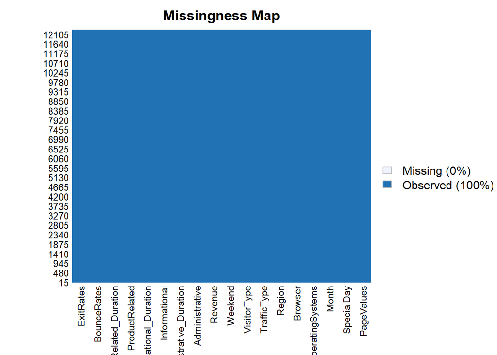

```r
#visualizing missing data
library(Amelia)
missmap(shoppers)
```

From the map, we observe that all the data has observation, this implies that the the missing values are not as significant in the entire datsset, hence we will omit the missing values

```r
#omit missing data

shoppers <- na.omit(shoppers)
colSums(is.na(shoppers))
```

```
##          Administrative Administrative_Duration           Informational
##                       0                       0                       0
##  Informational_Duration          ProductRelated ProductRelated_Duration
##                       0                       0                       0
##             BounceRates               ExitRates              PageValues
##                       0                       0                       0
##              SpecialDay                   Month        OperatingSystems
##                       0                       0                       0
##                 Browser                  Region             TrafficType
##                       0                       0                       0
##             VisitorType                 Weekend                 Revenue
##                       0                       0                       0
```

Our data is now complete without any missing data

### Consistency

```r
#checking for duplicate values
duplicated <- shoppers[duplicated(shoppers), ]
duplicated
```

```
##      Administrative Administrative_Duration Informational
##   1:              0                       0             0
##   2:              0                       0             0
##   3:              0                       0             0
##   4:              0                       0             0
##   5:              0                       0             0
##  ---
## 113:              0                       0             0
## 114:              0                       0             0
## 115:              0                       0             0
## 116:              0                       0             0
## 117:              0                       0             0
##      Informational_Duration ProductRelated ProductRelated_Duration BounceRates
##   1:                      0              1                       0         0.2
##   2:                      0              1                       0         0.2
```

[output cut: 33 more lines]

There are a total of 117 duplicate records in the dataset. As this is a website, such records are very likely to be similar hence we will retain this records

### Outliers

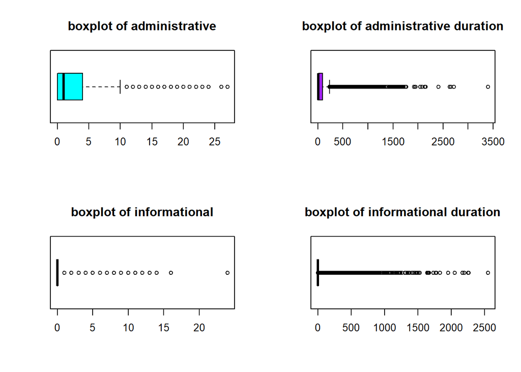

```r
#checking for outliers

#plotting boxplots for all the numerical variables
par(mfrow=c(2,2))
boxplot((shoppers$Administrative), horizontal = TRUE, col = 'cyan', main = "boxplot of administrative")

boxplot((shoppers$Administrative_Duration), horizontal = TRUE, col = 'purple', main = "boxplot of administrative duration")

boxplot((shoppers$Informational), horizontal = TRUE, col = 'violet', main = "boxplot of informational")

boxplot((shoppers$Informational_Duration), horizontal = TRUE, col = 'red', main = "boxplot of informational duration")
```

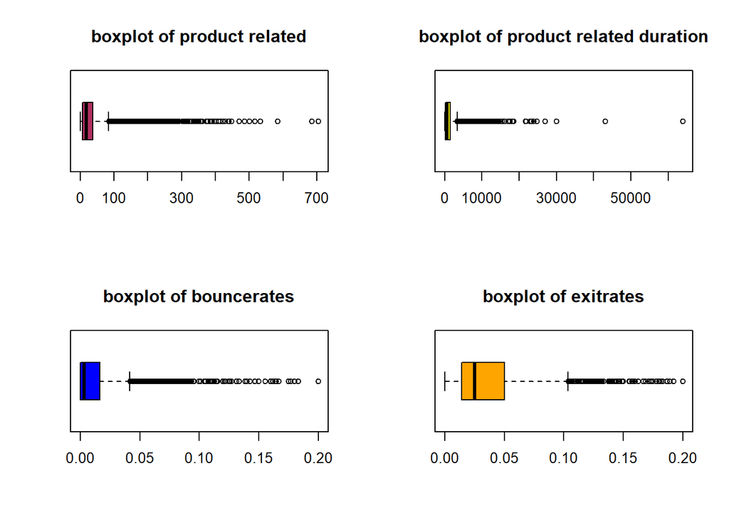

```r
boxplot((shoppers$ProductRelated), horizontal = TRUE, col = 'maroon', main = "boxplot of product related")

boxplot((shoppers$ProductRelated_Duration), horizontal = TRUE, col = 'yellow', main = "boxplot of product related duration")

boxplot((shoppers$BounceRates), horizontal = TRUE, col = 'blue', main = "boxplot of bouncerates")

boxplot((shoppers$ExitRates), horizontal = TRUE, col = 'orange', main = "boxplot of exitrates")
```

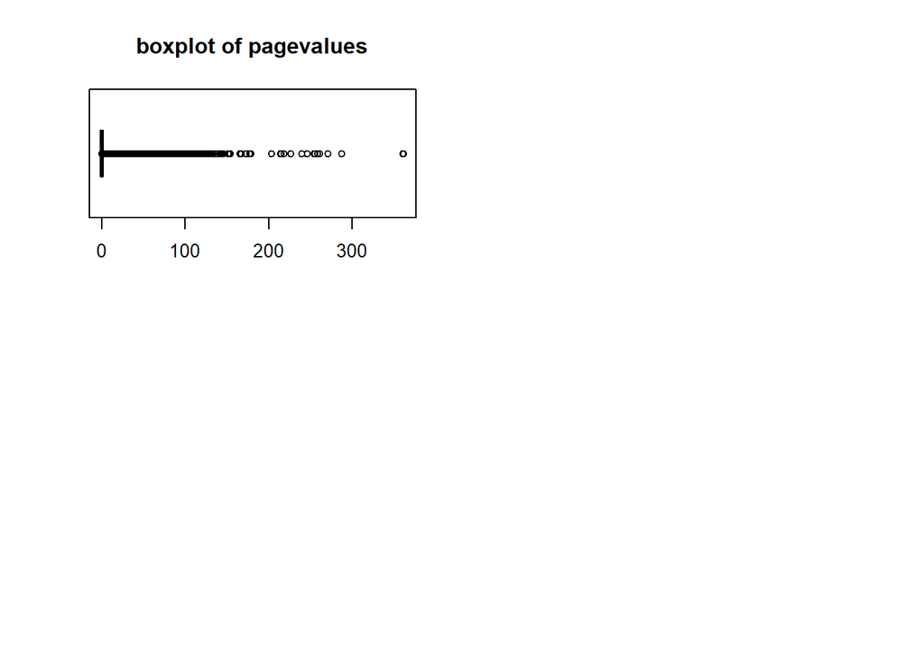

```r
boxplot((shoppers$PageValues), horizontal = TRUE, col = 'pink', main = "boxplot of pagevalues")
```

*Observations*

For the website pages, Administarive, Informational, and ProductRelated, the most frequented page is the product related which has outlier observations of 700 visits. These are a lot of visits as compared to the other pages that both have observations of a maximum of 25.

For the durations taken while on the pages, The product related page has 3 outlier observations of over 30,000 (This means there were visitors who spent more than 30,000 seconds on this pages, this is equivalent to 8 hours). Both the administrative duration and the informational duration have a few outlie observations over 2,500

For the bouncerates and exit rates, we have more outlier values in the boucerates variable than in the exitrates variable, but both variables have extreemes at around 20%

For the pagevalues, we have one extreme observation beyond 300. This seems like it is a valid observation as we have equally extreme observations in the page features. This could be the page value of the person who spent 8 hours on a single page

## 4. Univariate Analysis

```r
#library(psych)
#obtaining the statistical properties of the variables
describe(shoppers)
```

```
##                         vars     n    mean      sd median trimmed    mad min
## Administrative             1 12316    2.32    3.32   1.00    1.63   1.48   0
## Administrative_Duration    2 12316   80.91  176.86   8.00   42.19  11.86  -1
## Informational              3 12316    0.50    1.27   0.00    0.18   0.00   0
## Informational_Duration     4 12316   34.51  140.83   0.00    3.60   0.00  -1
## ProductRelated             5 12316   31.76   44.49  18.00   22.78  19.27   0
## ProductRelated_Duration    6 12316 1196.04 1914.37 599.77  821.41 743.05  -1
## BounceRates                7 12316    0.02    0.05   0.00    0.01   0.00   0
## ExitRates                  8 12316    0.04    0.05   0.03    0.03   0.02   0
## PageValues                 9 12316    5.90   18.58   0.00    1.30   0.00   0
## SpecialDay*               10 12316    1.31    1.00   1.00    1.00   0.00   1
## Month*                    11 12316    6.16    2.37   7.00    6.35   1.48   1
## OperatingSystems*         12 12316    2.12    0.91   2.00    2.06   0.00   1
## Browser*                  13 12316    2.36    1.72   2.00    2.00   0.00   1
## Region*                   14 12316    3.15    2.40   3.00    2.79   2.97   1
## TrafficType*              15 12316    4.07    4.02   2.00    3.22   1.48   1
## VisitorType*              16 12316    2.72    0.69   3.00    2.90   0.00   1
## Weekend                   17 12316     NaN      NA     NA     NaN     NA Inf
## Revenue                   18 12316     NaN      NA     NA     NaN     NA Inf
##                              max    range  skew kurtosis    se
## Administrative             27.00    27.00  1.96     4.69  0.03
## Administrative_Duration  3398.75  3399.75  5.61    50.48  1.59
## Informational              24.00    24.00  4.03    26.89  0.01
## Informational_Duration   2549.38  2550.38  7.57    76.18  1.27
## ProductRelated            705.00   705.00  4.34    31.17  0.40
## ProductRelated_Duration 63973.52 63974.52  7.26   137.03 17.25
## BounceRates                 0.20     0.20  2.95     7.75  0.00
## ExitRates                   0.20     0.20  2.15     4.04  0.00
## PageValues                361.76   361.76  6.38    65.53  0.17
## SpecialDay*                 6.00     5.00  3.30     9.89  0.01
## Month*                     10.00     9.00 -0.83    -0.37  0.02
## OperatingSystems*           8.00     7.00  2.07    10.45  0.01
## Browser*                   13.00    12.00  3.24    12.73  0.02
## Region*                     9.00     8.00  0.98    -0.15  0.02
## TrafficType*               20.00    19.00  1.96     3.48  0.04
## VisitorType*                3.00     2.00 -2.06     2.28  0.01
## Weekend                     -Inf     -Inf    NA       NA    NA
## Revenue                     -Inf     -Inf    NA       NA    NA
```

*Observations*

```r
# obtaining the statistical summary of the data
summary(shoppers)
```

```
##  Administrative   Administrative_Duration Informational
##  Min.   : 0.000   Min.   :  -1.00         Min.   : 0.000
##  1st Qu.: 0.000   1st Qu.:   0.00         1st Qu.: 0.000
##  Median : 1.000   Median :   8.00         Median : 0.000
##  Mean   : 2.318   Mean   :  80.91         Mean   : 0.504
##  3rd Qu.: 4.000   3rd Qu.:  93.50         3rd Qu.: 0.000
##  Max.   :27.000   Max.   :3398.75         Max.   :24.000
##
##  Informational_Duration ProductRelated   ProductRelated_Duration
##  Min.   :  -1.00        Min.   :  0.00   Min.   :   -1.0
##  1st Qu.:   0.00        1st Qu.:  7.00   1st Qu.:  185.0
##  Median :   0.00        Median : 18.00   Median :  599.8
##  Mean   :  34.51        Mean   : 31.76   Mean   : 1196.0
##  3rd Qu.:   0.00        3rd Qu.: 38.00   3rd Qu.: 1466.5
##  Max.   :2549.38        Max.   :705.00   Max.   :63973.5
##
##   BounceRates         ExitRates         PageValues      SpecialDay
##  Min.   :0.000000   Min.   :0.00000   Min.   :  0.000   0  :11065
##  1st Qu.:0.000000   1st Qu.:0.01429   1st Qu.:  0.000   0.2:  178
##  Median :0.003119   Median :0.02512   Median :  0.000   0.4:  243
##  Mean   :0.022152   Mean   :0.04300   Mean   :  5.896   0.6:  351
##  3rd Qu.:0.016684   3rd Qu.:0.05000   3rd Qu.:  0.000   0.8:  325
##  Max.   :0.200000   Max.   :0.20000   Max.   :361.764   1  :  154
##
##      Month      OperatingSystems    Browser         Region      TrafficType
##  May    :3363   2      :6593     2      :7951   1      :4774   2      :3909
##  Nov    :2998   1      :2582     1      :2459   3      :2402   1      :2444
##  Mar    :1894   3      :2552     4      : 735   4      :1179   3      :2051
##  Dec    :1727   4      : 478     5      : 467   2      :1134   4      :1069
##  Oct    : 549   8      :  79     6      : 174   6      : 804   13     : 737
##  Sep    : 448   6      :  19     10     : 163   7      : 761   10     : 450
##  (Other):1337   (Other):  13     (Other): 367   (Other):1262   (Other):1656
##             VisitorType     Weekend         Revenue
##  New_Visitor      : 1694   Mode :logical   Mode :logical
##  Other            :   85   FALSE:9451      FALSE:10408
##  Returning_Visitor:10537   TRUE :2865      TRUE :1908
##
##
##
##
```

**Histograms**

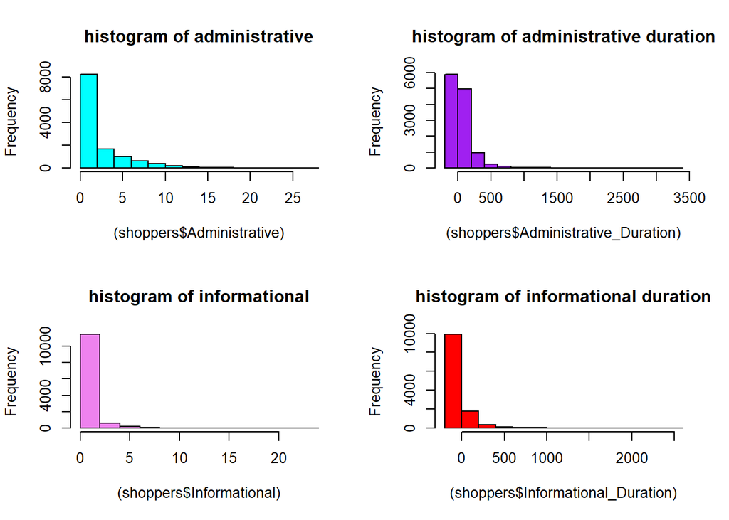

```r
#plotting multiple histograms of the numerical variables
par(mfrow=c(2,2))

#histogram of administrative
hist((shoppers$Administrative), col = 'cyan', main = "histogram of administrative")

#histogram of administrative duration
hist((shoppers$Administrative_Duration), col = 'purple', main = "histogram of administrative duration")

#histogram of informational
hist((shoppers$Informational), col = 'violet', main = "histogram of informational")

#histogram of informational duration
hist((shoppers$Informational_Duration), col = 'red', main = "histogram of informational duration")
```